# Ejercicios Organizar

Jorge Loría

October 8, 2017

Para esta clase se le han entregado 3 sets de datos:

- Infant_Deaths.csv
- Life_tables_worlds.csv
- Tasa_Basica_pasiva.xlsx

La idea es que los pase a la forma que se le indica en su ejercicio correspondiente. Usando los comandos que aprendió en la clase pasada del paquete `tidyr`. Recuerde que este se carga usando el comando `library(tidyr)`

## Ejercicio 1

Los datos de `Infant_Deaths` indican la cantidad de muertes de niños en los últimos años en varios países. Cargue los datos de `Infant_Deaths` y reacomódelos para que se vean como la siguiente imagen:

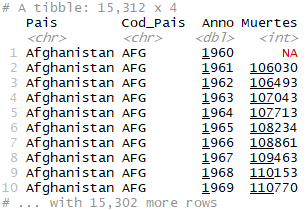

Solucion infant deaths

## Ejercicio 2

Los datos de `Tasa_Basica_pasiva`, indican la tasa básica pasiva diaria que se experimentó en Costa Rica en los últimos años, según el Banco Central de Costa Rica. Reacomódelos para que tomen la siguiente forma:

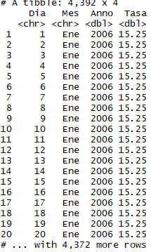

Solucion tasa básica pasiva

**Sugerencia:** la función `sub` sirve para cambiar substrings por otros substrings. Puede usarla con mutate, para cambiar comas por puntos, para transformar en números.

## Ejercicio 3

Una herramienta que se usa mucho en cursos de matemática actuarial, son las tablas de vida. Esta tabla se obtuvo de la página de la organización mundial de la salud (WHO, por sus siglas en inglés). La idea es que apoyándose en las funciones de `tidyr` y `dplyr`, consiga reorganizarla para que tome la siguiente forma:

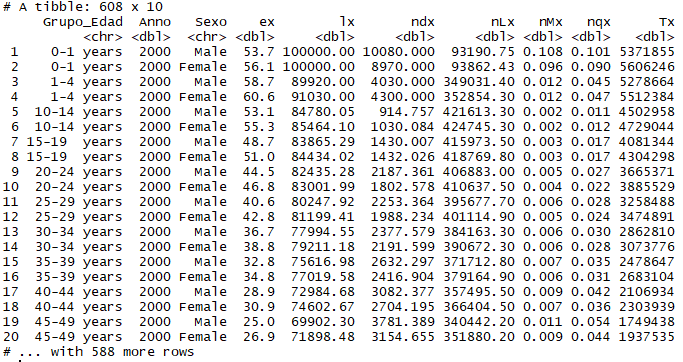

Solucion Life World Table

Luego, separe la columna de `Grupo_Edad` de forma tal que se incluyan ahora dos nuevas columnas, una de edad inicial y otra de edad final, ambas numéricas. Seleccione únicamente las columnas de Edades, Anno, Sexo y ex. La columna ex, lo que representa es la cantidad de años que se espera que la persona viva de ahora en adelante.

Vamos a calcular el promedio de vida de las personas que nacieron en cada año.

Primero, reordene el dataframe de forma tal que quede una única columna de edades, y en otra columna se indique si es de inicio o es de final.

Haga una nueva columna en donde se indique cuanto es el Anno menos la Edad, puede ponerle Nacimiento a esta columna. Y haga otra columna donde se calcula la suma de ex con la edad.

Ahora, para cada año de nacimiento y sexo, calcule el promedio de esta última columna creada.

Luego, vamos a ver porqué este procedimiento es incorrecto para obtener la esperanza al nacer.